# This is Assignment 09 - Michael Navarro

## Requirement 04

Numpy arrays are at face value very similar to Python Lists. In fact, it is failry easy to interchange the two if doing simple operations. Additionally, they are also very syntactically similar and both can be manipulated in fairly similar ways. The biggest difference arises once someone takes a peek under the hood, so to say. Numpy arrays are more akin to C style arrays in that only the same type may exist in the array and they are primitive types to the fullest extent of the definition. Python Lists on the other hand are arrays of pointers to an object stored in memory where additional information about the element is stored. This is how Python Lists can have the added bonus of storing any kind of type at once in the same list.

The biggest negative the Python Lists incur is their speed and ability to do more complex operations. This is due to how the Lists are set up in memory. On the other hand, their flexibility is a tremendous asset that allows them to act as something more than a list. In sense they can act like structures to a certain degree. Numpy arrays, as previously stated, follow more static typing norms which means they require less memory space and are able to have operations done on the array entries at a much faster rate. As with most things in the coding world, every tool has their use, it is up to the coder to know which tool is best for the job and, more importantly, how the tool actually works and how to use it.

## Requirement 05

Variable typing in Python is Dynamic, in that while a variable may be declared and initialized with a certain type, the typing can change on the fly during runtime. This is mainly due to the fact that Python is not a compiled language in the traditional sense like the C language. Instead, Python has an interpreter that acts as an intermediary during runtime that converts Python code into machine language. This allows Python to be able to do nifty tricks, like changing the typing of a variable. Languages like C rely on consitency and compiled code to work and interact in a certain way. In fact, depending on the IDE and compiler, C won't even let you compile correctly if the typing of a variable is changed in your code.

As previously stated, there are pros and cons to both of these tools. Python's flexibility means the learning curve and level of entry is much lower than other languages. Javascript also "suffers" from dynmaic typing and so typescript was born and the cult like following of using triple equals because double equals doesn't check if two variables are of the same type before comparing. Funnily enough, it actually does, the very first thing double equals does is check types and then coerce the typing of each variable with a small and strict algorithm. I digress though, again, languages and language features are tools and like any tool it can be mishandled and used in the wrong situation unless proper knowledge and wisdom of the tool is accrued and practices are adhered to.

## Requirement 06

Integer storage in Python comes with a higher overhead cost than a program like C because an integer in Python can be argued to not technically be an integer. Instead it is an object that acts like an integer. In C integers are actually integers and come in different sizes and what is called signed and unsigned variants. Unsigned integers can not be negative while signed inegers can, hence they are either "-" or "+" signed. There are, again, pros and cons to all the characteristics of C integers. One of the greatest pros that Python integers have over other languages that rely on "real" integers is that Python can do computations with incredibly large numbers that would not fit inside an integer buffer size of languages like C. This has helped Python become one of the go to languages for mathmatical operations.

## Requirement 07

```python
# List converion, execute the following requirements
# 1. Create a list: L1 of numbers 1-20
# 2. Conver the entries of L1 to strings
# 3. Store the converted entries into another list: L2

L1 = list(range(1, 21))
L2 = [str(num) for num in L1]

print(f'Contents of L1: {L1}')
print(f'Contents of L2: {L2}')
```

```
Contents of L1: [1, 2, 3, 4, 5, 6, 7, 8, 9, 10, 11, 12, 13, 14, 15, 16, 17, 18, 19, 20]
Contents of L2: ['1', '2', '3', '4', '5', '6', '7', '8', '9', '10', '11', '12', '13', '14', '15', '16', '17', '18', '19', '20']
```

## Requirement 08

```python
# Demonstrate a geterogeneous list with at least 5 different data types
hetero_list = [1, '1', (0, 1), {"one": "1"}, 1.0]

print(f'Entry 1 is of type: {type(hetero_list[0])}')
print(f'Entry 2 is of type: {type(hetero_list[1])}')
print(f'Entry 3 is of type: {type(hetero_list[2])}')
print(f'Entry 4 is of type: {type(hetero_list[3])}')
print(f'Entry 5 is of type: {type(hetero_list[4])}')
```

```
Entry 1 is of type: <class 'int'>
Entry 2 is of type: <class 'str'>
Entry 3 is of type: <class 'tuple'>
Entry 4 is of type: <class 'dict'>
Entry 5 is of type: <class 'float'>
```

## Requirement 09

```python
# Create a python array and with the following criteria
# 1. Use built in array module
# 2. Demonstrate the following operations
#   - append, insert, index, insert an element of a different type

import array

test_array = list(range(1, 11))
array_array = array.array('i', test_array)

print(f'Result of array.array method: {array_array}')

array_array.append(11)
print(f'Result of append: {array_array}')

array_array.insert(0, 0)
print(f'Result of insert: {array_array}')

print(f'Index of element "6": {array_array.index(6)}')

array_array.insert(1, 0.5)
print(f'Result of insert: {array_array}')
```

```
Result of array.array method: array('i', [1, 2, 3, 4, 5, 6, 7, 8, 9, 10])
Result of append: array('i', [1, 2, 3, 4, 5, 6, 7, 8, 9, 10, 11])
Result of insert: array('i', [0, 1, 2, 3, 4, 5, 6, 7, 8, 9, 10, 11])
Index of element "6": 6
```

```
---------------------------------------------------------------------------
TypeError                                 Traceback (most recent call last)
~\AppData\Local\Temp/ipykernel_15612/478281620.py in <module>
     19 print(f'Index of element "6": {array_array.index(6)}')
     20
---> 21 array_array.insert(1, 0.5)
     22 print(f'Result of insert: {array_array}')

TypeError: integer argument expected, got float
```

## Requirement 10

```python
# Create a NumPy arrary with the following criteria
# 1. name: one_d_array
# 2 contents: 10 floats
# 3. Demonstrate the following operations
#   - implicit casting, explicit casting

import numpy as np

one_d_array = np.array([1.0 , 2, 3, 4, 5, 6, 7, 8, 9, 10])
print(f'Implicit cast of [1.0 , 2, 3, 4, 5, 6, 7, 8, 9, 10]:\n{one_d_array}')

one_d_array = np.array([1 , 2, 3, 4, 5, 6, 7, 8, 9, 10], dtype='float32')
print(f'Explicit cast of [1 , 2, 3, 4, 5, 6, 7, 8, 9, 10], dtype="float32":\n{one_d_array}')
```

```
Implicit cast of [1.0 , 2, 3, 4, 5, 6, 7, 8, 9, 10]:
[ 1.  2.  3.  4.  5.  6.  7.  8.  9. 10.]
Explicit cast of [1 , 2, 3, 4, 5, 6, 7, 8, 9, 10], dtype="float32":
[ 1.  2.  3.  4.  5.  6.  7.  8.  9. 10.]
```

## Requirement 11

```python
# Use list comprehension to create a two-dimensional NumPy array with the following criteria
# 1. name: two_d_array
# 2. dimensions: 5 x 3
# 3. Replicate:
#   [[1 2 3]
#   [2 3 4]
#   [3 4 5]
#   [4 5 6]
#   [5 6 7]]

two_d_array = np.array([range(num, num + 3) for num in [1, 2, 3, 4, 5]])
print(two_d_array)
```

```
[[1 2 3]
 [2 3 4]
 [3 4 5]
 [4 5 6]
 [5 6 7]]
```

## Requirement 12

```python
# Create a 3-Dimensional array with the following criteria
# 1. name: three_d_array
# 2. contents: random numbers 0-99
# 3. dimensions: 3 x 5 x 5
# 4. display size in bytes of array

three_d_array = np.random.randint(0, 99, size=(3, 5, 5))
print(f'Size of array: {three_d_array.size}')
print(f'Array Contents:\n{three_d_array}')
```

```
Size of array: 75
Array Contents:
[[[75  5 46 66 49]
  [10 43 11 23 41]
  [82 64  6 67 59]
  [16 10  6 35 64]
  [57 84 67 26 80]]

 [[32 55 74 69 39]
  [48 24 39 30 19]
  [49 27  0 29 78]
  [31 48 91 58  3]
  [29 60 82 74 62]]

 [[24 79 94 57 96]
  [81 91 86 41 88]
  [12 67 72  1  1]
  [69 93 81  6 79]
  [11  9 65  7 81]]]
```

## Requirement 13

```python
# Demonstrate accessing 4 different individual elements of the three_d_array

print(f'First element of first array: {three_d_array[0, 0, 0]}')
print(f'First element of second array: {three_d_array[1, 0, 0]}')
print(f'First element of third array: {three_d_array[2, 0, 0]}')

print(f'Middle element of first array: {three_d_array[0, 2, 2]}')
print(f'Middle element of second array: {three_d_array[1, 2, 2]}')
print(f'Middle element of third array: {three_d_array[2, 2, 2]}')

print(f'Last element of first array: {three_d_array[0, 4, 4]}')
print(f'Last element of second array: {three_d_array[1, 4, 4]}')
print(f'Last element of third array: {three_d_array[2, 4, 4]}')
```

```
First element of first array: 75
First element of second array: 32
First element of third array: 24
Middle element of first array: 6
Middle element of second array: 0
Middle element of third array: 72
Last element of first array: 80
Last element of second array: 62
Last element of third array: 81
```

## Requirement 15

```python
# Using one_d_array demonstrate slicing...
# 1. First 7 elements
# 2. All after index 7
# 3. From index 3-8
# 4. Every other element
# 5. Elements reversed
# 6. Reverse every other elements from index 7

print(f'First 7 elements: {one_d_array[:7]}')
print(f'Elements after index 7: {one_d_array[7:]}')
print(f'Elements from index 3 to index 8: {one_d_array[3:8]}')
print(f'Every other element: {one_d_array[::2]}')
print(f'Elements reversed: {one_d_array[::-1]}')
print(f'Reverse every other element from index 7: {one_d_array[7::-2]}')
```

```
First 7 elements: [1. 2. 3. 4. 5. 6. 7.]
Elements after index 7: [ 8.  9. 10.]
Elements from index 3 to index 8: [4. 5. 6. 7. 8.]
Every other element: [1. 3. 5. 7. 9.]
Elements reversed: [10.  9.  8.  7.  6.  5.  4.  3.  2.  1.]
Reverse every other element from index 7: [8. 6. 4. 2.]
```

## Requirement 16

```python
# Using two_d_array, demonstrate slicing...
# 1. First 2 rows and first 2 columns
# 2. All rows, every other column
# 3. All columns every other row
# 4. Extracting a subarray

print(f'Original Array:\n{two_d_array}')
print(f'First two rows and columns:\n{two_d_array[:2, :2]}')
print(f'All rows, every other column:\n{two_d_array[:, ::2]}')

subarray = two_d_array[:2, :3]
print(f'Subarray of size 2 x 3:\n{subarray}')
```

```
Original Array:
[[1 2 3]
 [2 3 4]
 [3 4 5]
 [4 5 6]
 [5 6 7]]
First two rows and columns:
[[1 2]
 [2 3]]
All rows, every other column:
[[1 3]
 [2 4]
 [3 5]
 [4 6]
 [5 7]]
Subarray of size 2 x 3:
[[1 2 3]
 [2 3 4]]
```

## Requirement 17

```python
# Use NumPy's arrange and reshape to create a 10x10 arrarywith values from 1-100

big_array = np.arange(1, 101).reshape((10, 10))
print(f'{big_array}')
```

```
[[  1   2   3   4   5   6   7   8   9  10]
 [ 11  12  13  14  15  16  17  18  19  20]
 [ 21  22  23  24  25  26  27  28  29  30]
 [ 31  32  33  34  35  36  37  38  39  40]
 [ 41  42  43  44  45  46  47  48  49  50]
 [ 51  52  53  54  55  56  57  58  59  60]
 [ 61  62  63  64  65  66  67  68  69  70]
 [ 71  72  73  74  75  76  77  78  79  80]
 [ 81  82  83  84  85  86  87  88  89  90]
 [ 91  92  93  94  95  96  97  98  99 100]]
```

## Requirement 18

```python
# Using one_d_array create...
# 1. A row vector
# 2. A column vector

print(f'Original array:\n{one_d_array}')
print(f'Row vector: {one_d_array[np.newaxis, :]}')
print(f'Column vector:\n{one_d_array[:, np.newaxis]}')
```

```
Original array:
[ 1.  2.  3.  4.  5.  6.  7.  8.  9. 10.]
Row vector: [[ 1.  2.  3.  4.  5.  6.  7.  8.  9. 10.]]
Column vector:
[[ 1.]
 [ 2.]
 [ 3.]
 [ 4.]
 [ 5.]
 [ 6.]
 [ 7.]
 [ 8.]
 [ 9.]
 [10.]]
```

## Requirement 19

A NumPy universal function (ufunc) is a a special vectorized operation that is designed to execute at the lower compiled layer of NumPy. They work by applying the operation to each element of an array and doing so quickly because they do not have to worry about as many of the hinderances of being at a higher level of the Python Interpretation layer chain. This is especially helpful when doing repeated operations on large size arrays as it essentially eliminates type checking and operation lookups.

## Requirement 20

```python
# Demonstrate the use of the out argument

input_array = np.random.randint(0, 20, size=(5))
output_array = np.empty(5)
np.multiply(input_array, 2, out=output_array)

print(f'Input Array: {input_array}')
print(f'Output Array: {output_array}')
```

```
Input Array: [10  2  5  0  1]
Output Array: [20.  4. 10.  0.  2.]
```

## Requirement 21

```python
# Use aggregates to show the product of all elements of one_d_array

print(f'Product of all elements in one_d_array: {np.multiply.reduce(one_d_array)}')
```

```
Product of all elements in one_d_array: 3628800.0
```

## Requirement 22

```python
# Create NumPy arrays x and y and demonstrate...
# 1. multiply()
# 2. outer()
# 3. Result
# [[ 2  2  2  2  2]
#  [ 4  4  4  4  4]
#  [ 6  6  6  6  6]
#  [ 8  8  8  8  8]
#  [10 10 10 10 10]]

x = np.arange(1, 6)
y = np.full(5, 2)

print(f'Array X: {x}')
print(f'Array Y: {y}')
print(f'Multiply & Outer:\n{np.multiply.outer(x, y)}')
```

```
Array X: [1 2 3 4 5]
Array Y: [2 2 2 2 2]
Multiply & Outer:
[[ 2  2  2  2  2]
 [ 4  4  4  4  4]
 [ 6  6  6  6  6]
 [ 8  8  8  8  8]
 [10 10 10 10 10]]
```

## Requirement 23

```python
# Demonstrate Numpy's...
# 1. Sum, min & max functions
# 2. Time with %timeit
# 3. Compare with Python's sum, min & max

numpy_array = np.random.randint(1, 100, size=10)

print(f'Original Array: {numpy_array}')
print(f'Sum of Array: {np.sum(numpy_array)}')
print(f'Min of Array: {np.min(numpy_array)}')
print(f'Max of Array: {np.max(numpy_array)}')

print('\nSum Method Comparison Python Vs NumPy')
%timeit sum(numpy_array)
%timeit np.sum(numpy_array)
print('\nMin Method Comparison Python Vs NumPy')
%timeit min(numpy_array)
%timeit np.min(numpy_array)
print('\nMax Method Comparison Python Vs NumPy')
%timeit max(numpy_array)
%timeit np.max(numpy_array)
```

```
Original Array: [42 24 75 53 39 45 49 63 36 86]
Sum of Array: 512
Min of Array: 24
Max of Array: 86

Sum Method Comparison Python Vs NumPy
1.01 µs ± 3.03 ns per loop (mean ± std. dev. of 7 runs, 1000000 loops each)
2.69 µs ± 33 ns per loop (mean ± std. dev. of 7 runs, 100000 loops each)

Min Method Comparison Python Vs NumPy
835 ns ± 3.71 ns per loop (mean ± std. dev. of 7 runs, 1000000 loops each)
2.58 µs ± 27.5 ns per loop (mean ± std. dev. of 7 runs, 100000 loops each)

Max Method Comparison Python Vs NumPy
839 ns ± 1.24 ns per loop (mean ± std. dev. of 7 runs, 1000000 loops each)
2.48 µs ± 49.1 ns per loop (mean ± std. dev. of 7 runs, 100000 loops each)
```

## Requirement 24

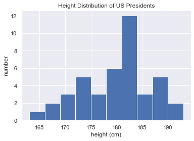

```python
# Use the file president_heights.csv to produce a histogram of U.S. President height information

import pandas as pd
import matplotlib.pyplot as plt
import seaborn; seaborn.set()

data = pd.read_csv('president_heights.csv')
heights = np.array(data['height(cm)'])

%matplotlib inline
plt.hist(heights)
plt.title('Height Distribution of US Presidents')
plt.xlabel('height (cm)')
plt.ylabel('number');
```

## Requirement 25

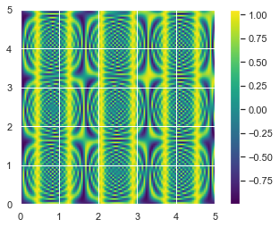

```python
# Use boradcasting and Matplotlib to plot produce a plot of a two-dimensional array

array_x = np.linspace(0, 19, 100)
array_y = np.linspace(0, 100, 100)[:, np.newaxis]

array_z = np.sin(array_x) ** 10 + np.cos(10 + array_y * array_x) * np.cos(array_x)

%matplotlib inline
import matplotlib.pyplot as plt

plt.imshow(array_z, origin='lower', extent=[0, 5, 0, 5],
           cmap='viridis')
plt.colorbar();
```

## Requirement 26

This was a very fun assignment! I learned an incredible amount about NumPy and its handy features. My favorite part were actually the last few requirements involving Matplotlib. I had a lot of fun messing with the variables and seeing their output. If I had more time to expirement, I would have like to create a mandala or some sort of complex symmetrical form. Overall, this has been the most enlightening assignment thus far and I can not wait to see what else is in store with these wonderful tools!